# Script 01: Pre-Processing

Steps involved:

1. sample-specific QC (by MAD)
2. ambient RNA detection & removal
3. doublet detection

```r
library(Seurat)
library(dplyr)
library(patchwork)
library(ggplot2)
library(SoupX)
```

Load a couple of helper functions:

```r
source("R/plotting.R")
source("R/quickndirty_helpers.R")
```

Current sample_id:

```r
current_sample <- "1015"
```

nMADs to use as cutoff:

```r
mad_cut = 5
```

Paths:

```r
# data:
data_path <- file.path("..", "data", "cellranger", current_sample, "outs")
# results:
results_path <- file.path("01_preprocess", current_sample)
if(!dir.exists(results_path)){
  dir.create(results_path, recursive = TRUE)
}
# storage for new desoupd counts matrix:
desoupd_path <- file.path(results_path, "soupx")
if(!dir.exists(desoupd_path)){
  dir.create(desoupd_path, recursive = TRUE)
}
```

Keep some canonical marker genes around for sanity checks & to inspect quality of ambient RNA removal. Caution: manual estimation of contamination fraction in SoupX with these markers tends to lead to over-correction

```r
# EXCLUSIVE marker genes
T_genes = c("Cd3d", "Cd3e", "Cd3g", "Ccl5")
B_genes = c("Cd79a", "Cd19", "Pax5", "Ebf1")
neutro_genes = c("Cd177", "Ltf", "Camp", "Ngp")
act_neutro_genes = c( "Mmp9", "Retnlg", "Csf3r")
ery_genes = c("Hba-a2", "Hbb-bs", "Hbb-bt", "Alas2", "Hba-a1")
dend_genes = c("Siglech", "Clec9a")
mono_genes = c("Ccr2", "Csf1r", "Cd14", "Cx3cr1")

ExclusiveGenesList = list(
  T_cells = T_genes,
  B_cells = B_genes,
  neutro = neutro_genes,
  act_neutro = act_neutro_genes,
  ery = ery_genes,
  dend = dend_genes,
  mono = mono_genes
  )
```

Cell cycle genes for cell cycle scoring (origin: https://github.com/hbc/tinyatlas/blob/master/cell_cycle/Mus_musculus.csv -> ensembl biomart for symbols)

```r
# load cell cycle genes
s_genes <- read.csv("../metadata/cell_cycle/mart_export_s.txt") %>% pull(3)
g2m_genes <- read.csv("../metadata/cell_cycle/mart_export_g2m.txt") %>% pull(3)
```

# Filtering

```r
# filtered counts
filtered <- Read10X_h5(file.path(data_path, "filtered_feature_bc_matrix.h5"))
# stick it with appropriate DKFZ projectID & sampleID
colnames(filtered) <- gsub(
  "-1$",
  paste0("-EPIG_A07_", current_sample),
  colnames(filtered))
```

Load metadata from exploratory first pass analysis with old cellranger output. The initial cell labels I assigned will prove useful

```r
unsouped_meta <- read.csv(file.path("results", "old_results", "FULL_metadata_with_labels", "metadata.csv"),
                          row.names = 1) %>%
  filter(mouse_id == current_sample) %>%
  select(cell_type_merged)

colnames(unsouped_meta) <- "old_label"
```

Create Seurat object

```r
seurat_obj <- CreateSeuratObject(filtered)
seurat_obj <- AddMetaData(
  seurat_obj,
  metadata = unsouped_meta
  )
```

Tag outliers by a) % mitochondrial reads b) log(total counts) and c) log(distinct feature counts). This type of filtering is inspired by https://www.sc-best-practices.org :

```r
# add QC info
seurat_obj$percent.mt <- PercentageFeatureSet(seurat_obj, pattern = "^mt")
seurat_obj$log1p_n_genes_by_counts <- log1p(seurat_obj$nFeature_RNA)
seurat_obj$log1p_total_counts <- log1p(seurat_obj$nCount_RNA)

# define metrics
metrics_to_tag <- list(
  c("log1p_total_counts", "counts_outlier"),
  c("log1p_n_genes_by_counts", "features_outlier"),
  c("percent.mt", "mito_outlier")
)

# loop through metrics
for (pair in metrics_to_tag) {
  metric <- pair[[1]]
  new_col <- pair[[2]]
  index <- mad_tagging(seurat_obj, metric, mad_cut)
  seurat_obj[[new_col]] <- ifelse(index, "yes", "no")
}
```

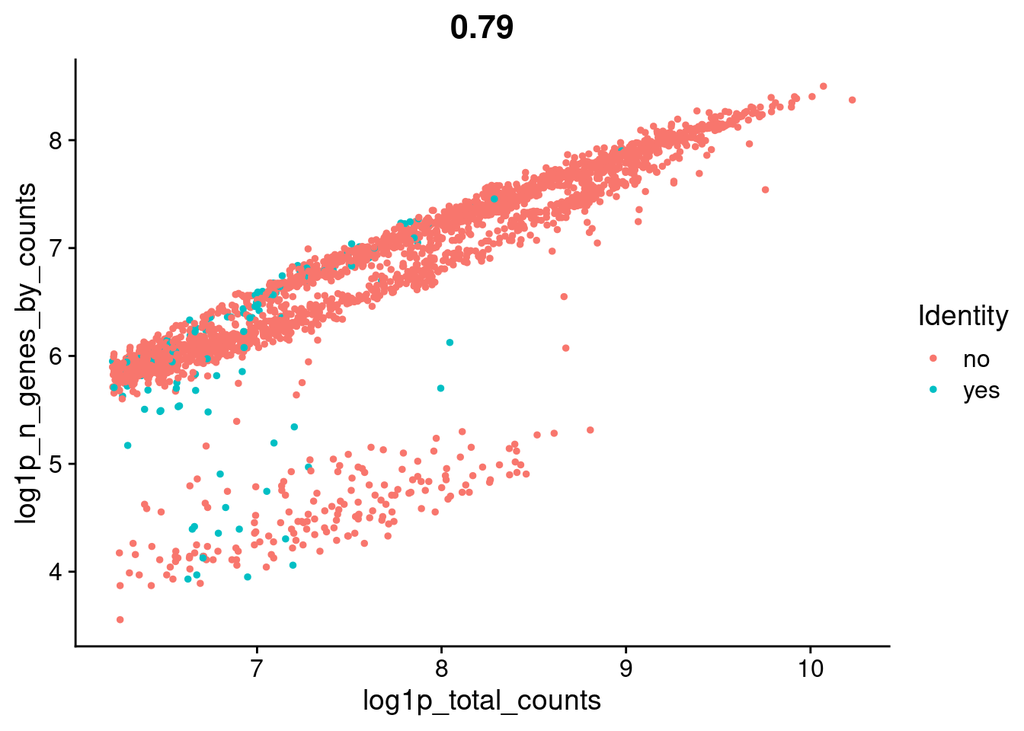

```r
# scatter + mito outliers
FeatureScatter(
  seurat_obj,
  "log1p_total_counts",
  "log1p_n_genes_by_counts",
  group.by = "mito_outlier")
```

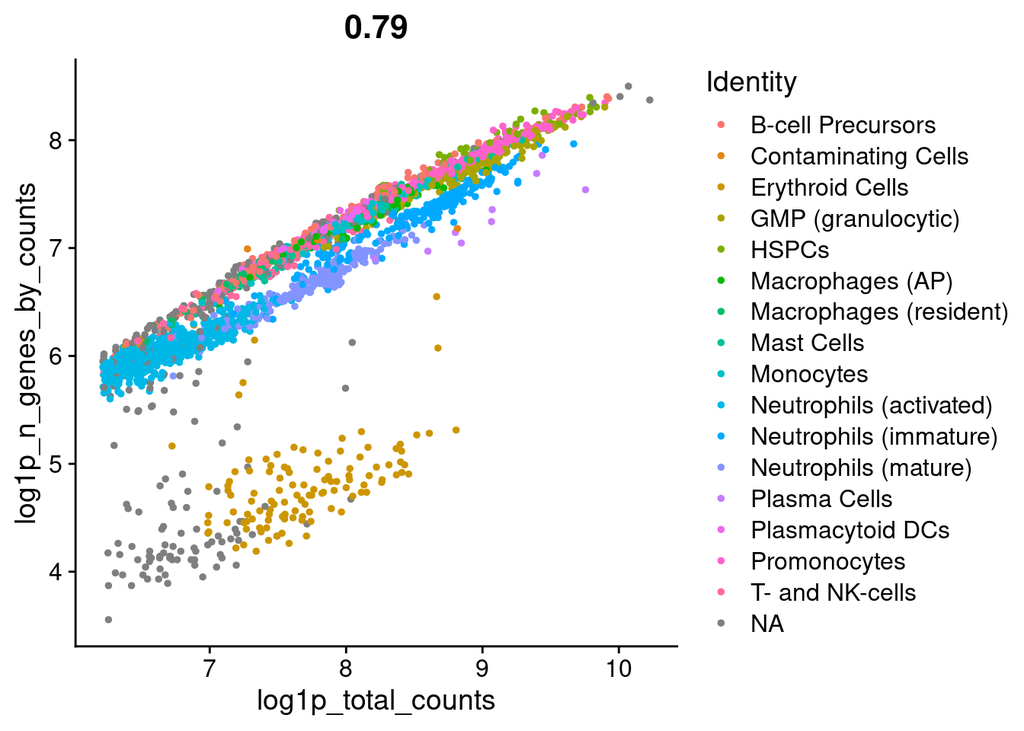

```r
# scatter + labels
FeatureScatter(
  seurat_obj,
  "log1p_total_counts",
  "log1p_n_genes_by_counts",
  group.by = "old_label")
```

-> As suspected, a lot of these outliers are actually bona fide erythrocytes (which have lower transcriptional complexity)

Get some quick clusters for inspection

```r
# run quickndirty clusters
seurat_obj <- run_standard_seurat(
  seurat_obj,
  npcs = 30)
```

```
## Modularity Optimizer version 1.3.0 by Ludo Waltman and Nees Jan van Eck
##
## Number of nodes: 2401
## Number of edges: 85561
##
## Running Louvain algorithm...
## Maximum modularity in 10 random starts: 0.8823
## Number of communities: 14
## Elapsed time: 0 seconds
```

Locate those outliers:

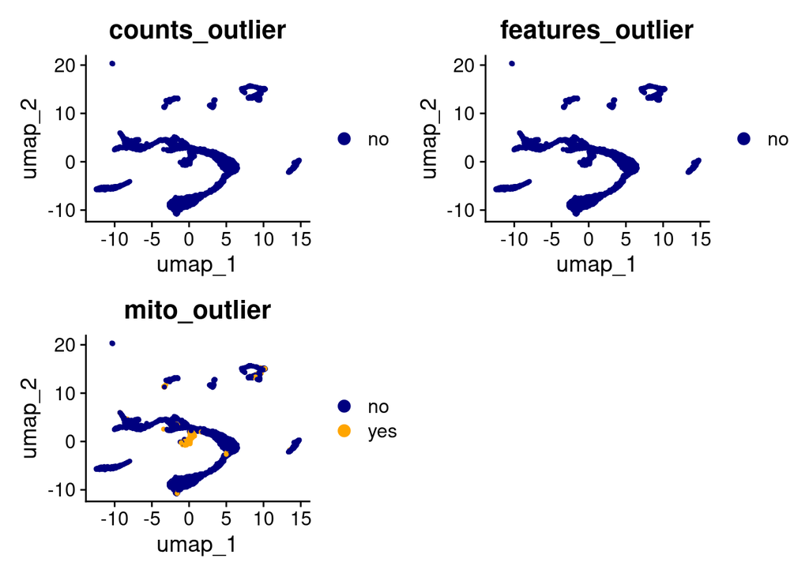

```r
# outlier position
save_dimplot(object = seurat_obj,
             reduction = "umap",
             category = c("counts_outlier","features_outlier", "mito_outlier"),
             title = "unfiltered_mad_outliers",
             folder = results_path,
             num_columns = 2,
             output_formats = "jpg")
```

Those are some tightly clustered outliers -> let’s remove ’em

```r
# remove mito outliers
seurat_subset <- subset(
  seurat_obj,
  subset = mito_outlier != "yes")
```

SoupX results are improved by providing cluster information, lets run it again on the cleaned object for good measure (probably wont change much)

```r
seurat_subset <- run_standard_seurat(
  seurat_subset,
  npcs = 30)
```

```
## Modularity Optimizer version 1.3.0 by Ludo Waltman and Nees Jan van Eck
##
## Number of nodes: 2275
## Number of edges: 83569
##
## Running Louvain algorithm...
## Maximum modularity in 10 random starts: 0.8761
## Number of communities: 15
## Elapsed time: 0 seconds
```

Inspect results:

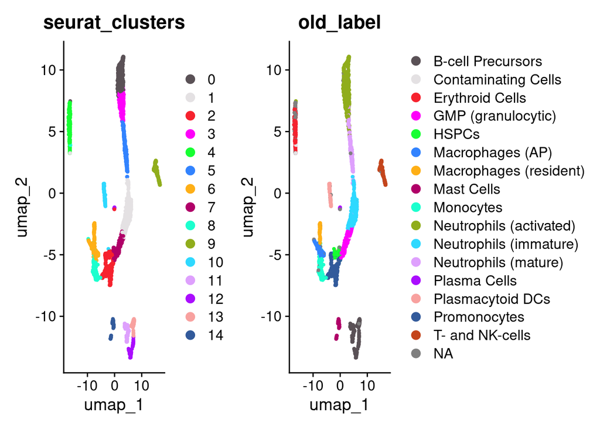

```r
# dimplot overview
save_dimplot(object = seurat_subset,
             reduction = "umap",
             category = c("seurat_clusters",
                          "old_label"),
             title = "overview",
             num_columns = 2,
             folder = results_path,
             output_formats = "jpg")
```

Get expression patterns for some cell type markers before altering the count matrix:

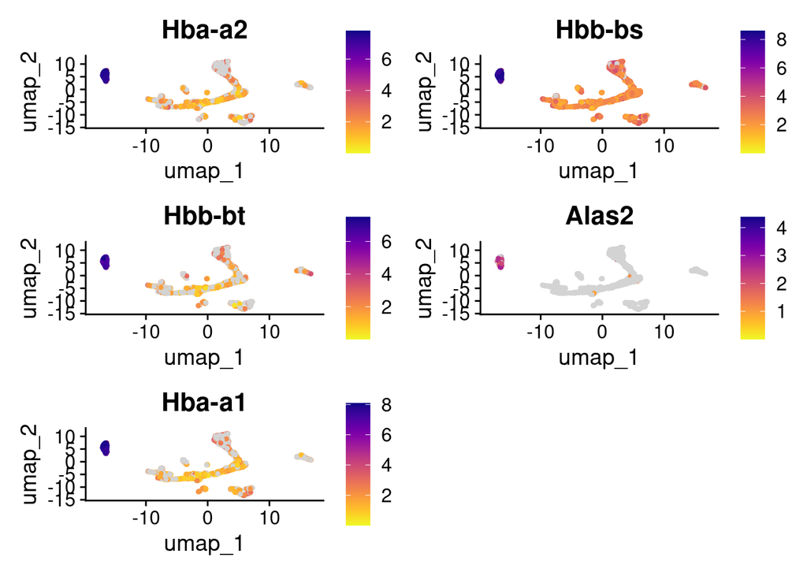

```r
# run this entire lapply for all markers:

# lapply(names(ExclusiveGenesList), function(genes) {
#   save_featureplot_big(
#     seurat_subset,
#     features = ExclusiveGenesList[[genes]],
#     title = paste0(genes, "_featurePlot"),
#     folder = results_path,
#     output_formats = "jpg")
# }
# )

# ery markers as example:
save_featureplot_big(
  seurat_subset,
  features = ExclusiveGenesList[["ery"]],
  title = paste0("ery", "_featurePlot"),
  folder = results_path,
  output_formats = "jpg"
)
```

-> there’s clear hemoglobin expression in places where it shouldnt be. Makes sense since the samples were submitted to RBC lysis. A rationale to apply ambient RNA correction

# SoupX

NB: some of this code is straight from the SoupX vignette at https://cran.r-project.org/web/packages/SoupX/vignettes/pbmcTutorial.html

Load raw droplet data for background estimation of the soup:

```r
# raw droplets (for SoupX)
raw <- Read10X_h5(file.path(data_path,  "raw_feature_bc_matrix.h5"))
colnames(raw) <- gsub(
  "-1$",
  paste0("-EPIG_A07_", current_sample),
  colnames(raw))
```

Set up soup channel and update it with clusters & UMAP coordinates:

```r
# update initial feature-BC matrix for filtered cell subset
filtered_subset <- filtered[, colnames(filtered) %in% colnames(seurat_subset)]

# initiate soup channel
sc <- SoupChannel(raw, filtered_subset) # calcSoupProfile = FALSE in case you want to estimateSoup() manually

# make sure it overaps with seurat object for cluster transfer etc
stopifnot(identical(colnames(sc$toc), colnames(seurat_subset)))

# print top 100 contaminants for inspection
write.csv(head(sc$soupProfile[order(sc$soupProfile$est, decreasing = TRUE), ], n = 100),
          file.path(results_path, "top100_soup_ingredients.csv"))

# transfer seurat clusters
sc = setClusters(sc,
                 setNames(seurat_subset$seurat_clusters,
                          rownames(seurat_subset@meta.data)))

# transfer embedding
sc = setDR(sc,
           seurat_subset@reductions$umap@cell.embeddings[colnames(sc$toc), c("umap_1", "umap_2")])
```

Optional: perform initial estimation with manual markers (will NOT be used for correction):

```r
# add markers
useToEst = estimateNonExpressingCells(sc,
                                      nonExpressedGeneList = ExclusiveGenesList)
```

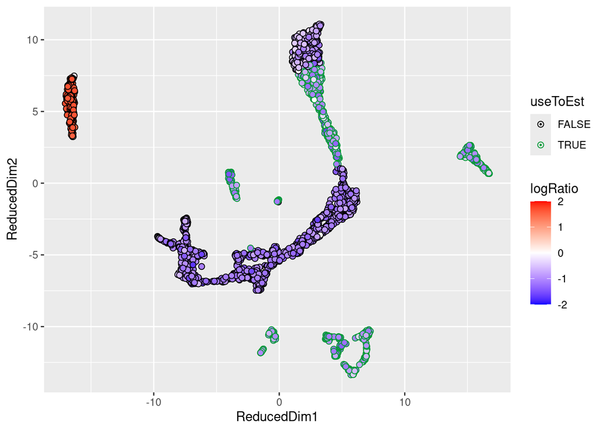

```r
# optional: plot all markers

# # plot markers (and reciprocally cells used for BG estimation)
# lapply(names(ExclusiveGenesList), function(name){
#   plotMarkerMap(sc,
#                 geneSet = ExclusiveGenesList[[name]],
#                 useToEst = useToEst[, name])
#   ggsave(file.path(results_path, paste0("MarkerMap_", name, ".jpg")))
# })

# exemplary: ery markers
  plotMarkerMap(sc,
                geneSet = ExclusiveGenesList[["ery"]],
                useToEst = useToEst[, "ery"])
```

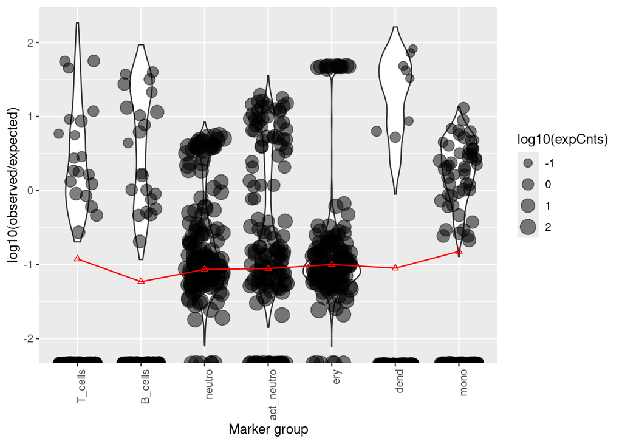

```r
plotMarkerDistribution(sc,
                       ExclusiveGenesList)
```

-> Ery and neutro marker genes really show a low observed/expected ratio in most cells with a small population defying the counts expected if the cells were only made of soup -> this confirms the initial suspicion of contaminating neutro/ery reads.

Optional: log manual estimation of contamination

```r
# calculate contamination %
sc = calculateContaminationFraction(sc,
                                    ExclusiveGenesList,
                                    useToEst = useToEst)
```

```
## Estimated global contamination fraction of 9.16%
```

```r
# log results
log_cont <- file.path(results_path,"log_contamination_estimates.txt")
sink(log_cont)
"Manual estimation:"
print(sc$metaData$rho %>% mean())
sink()
```

Automated estimation (WILL be used for estimation):

```r
sc = autoEstCont(sc)
```

[figure not shown]

```r
# log the result
sink(log_cont,
     append = TRUE)
"Automated estimation:"
print(sc$fit$rhoEst)
sink()
```

De-contamination:

```r
# adjust the counts based on estimated contamination
out = adjustCounts(sc,
                   roundToInt = TRUE)
```

```
## Expanding counts from 15 clusters to 2275 cells.
```

Inspect some results from the operation:

```r
# extract most zeroed counts (code from vignette)
cntSoggy = rowSums(sc$toc > 0)
cntStrained = rowSums(out > 0)
mostZeroed = tail(sort((cntSoggy - cntStrained)/cntSoggy), n = 200)
write.csv(
  as.data.frame(mostZeroed) %>%
            arrange(desc(mostZeroed)),
  file.path(results_path,"top200_removed_genes.csv"))
```

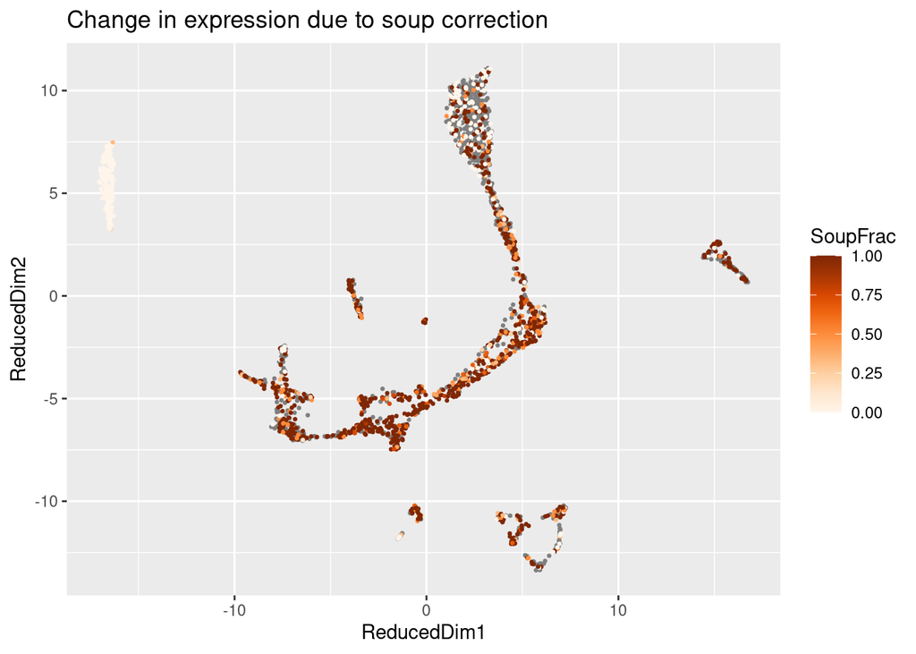

```r
# plot some %soup
# for (gene in c("Camp", "Mmp9", "Hba-a2", "Cd79a", "Cd3d", "Prtn3", "Cd34")){
#   plotChangeMap(sc,
#                 out,
#                 gene)
#   ggsave(file.path(results_path, paste0("ChangeMap_", gene, ".jpg")))
# }

# plot some %soup for erys
plotChangeMap(sc,
              out,
              "Hba-a2")
```

-> None of the hemoglobin alpha reads were removed in erythroid cells, while the majority of them were removed from non-erythroid cells

# Doublet flagging

```r
library(scDblFinder)
```

```r
# create sce from spare matrix
sce <- SingleCellExperiment(
  list(counts = out))

# detect doublets (I chose cluster = FALSE)
sce <- scDblFinder(sce)
```

```
## Creating ~1820 artificial doublets...
```

```
## Dimensional reduction
```

```
## Evaluating kNN...
```

```
## Training model...
```

```
## iter=0, 241 cells excluded from training.
```

```
## iter=1, 240 cells excluded from training.
```

```
## iter=2, 239 cells excluded from training.
```

```
## Threshold found:0.439
```

```
## 100 (4.4%) doublets called
```

# Final inspection & save results

Create Seurat object from de-soupd counts

```r
seurat_desoupd <- CreateSeuratObject(out,
                                     meta.data = seurat_subset@meta.data)
# normalize to plot gene expression
seurat_desoupd <- NormalizeData(seurat_desoupd)
```

```
## Normalizing layer: counts
```

Transfer UMAP & doublet metadata

```r
seurat_desoupd[["umap"]] <- CreateDimReducObject(
  embeddings = seurat_subset@reductions$umap@cell.embeddings,
  key = "umap_")
# transfer doublets
stopifnot(identical(colnames(sce), colnames(seurat_desoupd)))
seurat_desoupd$scDblFinder.class <- sce$scDblFinder.class
seurat_desoupd$scDblFinder.score <- sce$scDblFinder.score
```

Inspect doublet locations:

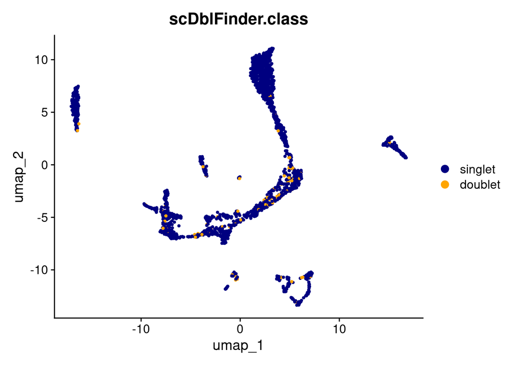

```r
# doublets overview
save_dimplot(object = seurat_desoupd,
             reduction = "umap",
             category = "scDblFinder.class",
             num_columns = 1,
             folder = results_path,
             output_formats = "jpg")
```

-> no cluster enriched for doublets. I will leave them in for now, all non-ery/non-neutro cells are precious for creating a reference map.

Check log-normalized expression of de-soupd marker genes:

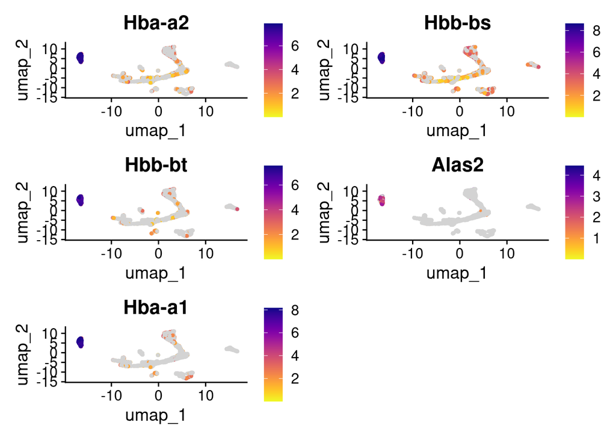

```r
# # desoupd markers overview
# lapply(names(ExclusiveGenesList), function(genes) {
#   save_featureplot(
#     seurat_desoupd,
#     features = ExclusiveGenesList[[genes]],
#     title = paste0("CLEANED_", genes, "_featurePlot"),
#     folder = results_path,
#     output_formats = "jpg")
# }
# )

# one ery marker
 save_featureplot_big(
    seurat_desoupd,
    features = ExclusiveGenesList[["ery"]],
    title = paste0("CLEANED_", "ery", "_featurePlot"),
    folder = results_path,
    output_formats = "jpg")
```

-> much better than before, while erythroid expression levels are conserved.

For QC completion’s sake, perform cell cycle scoring:

```r
seurat_desoupd <- CellCycleScoring(seurat_desoupd,
                                   s.features = s_genes,
                                   g2m.features = g2m_genes)
```

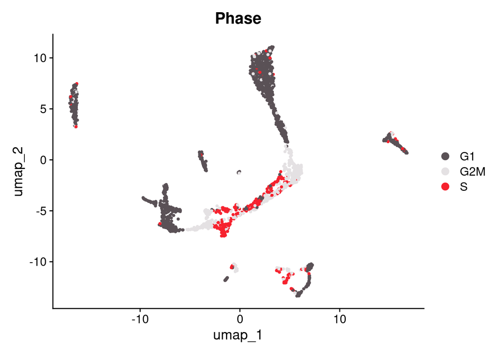

```r
save_dimplot(object = seurat_desoupd,
             reduction = "umap",
             category = c("Phase"),
             num_columns = 1,
             folder = results_path,
             output_formats = "jpg")
```

-> looks reasonable: stem and progenitors are show signs of cycling, the rest enriched for G1

Save the filtered & corrected sample data:

```r
# clean before saving
seurat_desoupd[["RNA"]]@layers$data <- NULL

# save seurat obj
saveRDS(
  seurat_desoupd,
  file.path(desoupd_path, paste0(current_sample, ".rds"))
)

# as well as components for scanpy access
save_seurat_comps(seurat_desoupd,
                  save_path = desoupd_path)
```

# Rinse & repeat for additional samples

```r
gc()
```

```
##            used  (Mb) gc trigger   (Mb)  max used   (Mb)
## Ncells 13691635 731.3   27271720 1456.5  27271720 1456.5
## Vcells 84711821 646.3  148150138 1130.3 123391680  941.5
```